# Machine Learning - Clustering and Dimensionality Reduction

# Check Class Distribution

## Dropped the NAs

```python
# Counting the classes
class_counts = df['diagnosis'].value_counts().reset_index()
class_counts.columns = ['Class Code', 'Count']
class_counts
```

|  | Class Code | Count |
| --- | --- | --- |
| 0 | 1 | 20 |
| 1 | 2 | 17 |
| 2 | 9 | 9 |
| 3 | 10 | 8 |
| 4 | 16 | 4 |
| 5 | 3 | 4 |
| 6 | 5 | 2 |
| 7 | 6 | 1 |
| 8 | 14 | 1 |
| 9 | 8 | 1 |
| 10 | 4 | 1 |

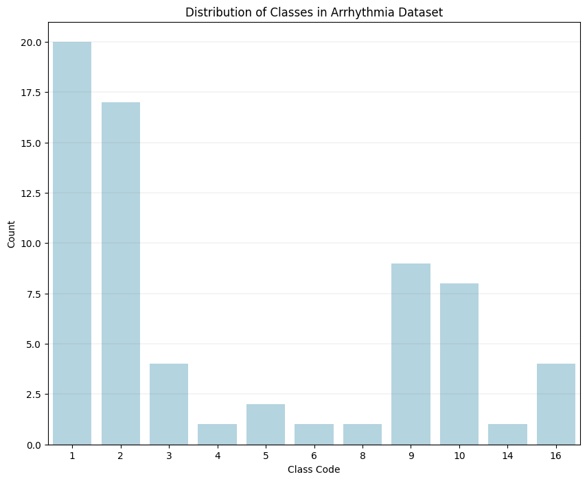

```python
# Plotting the class counts
plt.figure(figsize=(10, 8))
ax = sns.barplot(x='Class Code', y='Count', data=class_counts, color='lightblue')
plt.grid(axis='y', linestyle='-', color='gray', linewidth=0.25, alpha=0.5)
plt.title('Distribution of Classes in Arrhythmia Dataset')
plt.xlabel('Class Code')
plt.ylabel('Count')
plt.show()
```

## Raw Data without drop NAs

```python
df_not_dropped = pd.read_csv("data_arrhythmia.csv", sep=";", na_values="?")
```

```python
# Counting the classes
class_counts_not_dropped = df_not_dropped['diagnosis'].value_counts().reset_index()
class_counts_not_dropped.columns = ['Class Code', 'Count']
class_counts_not_dropped
```

|  | Class Code | Count |
| --- | --- | --- |
| 0 | 1 | 245 |
| 1 | 10 | 50 |
| 2 | 2 | 44 |
| 3 | 6 | 25 |
| 4 | 16 | 22 |
| 5 | 3 | 15 |
| 6 | 4 | 15 |
| 7 | 5 | 13 |
| 8 | 9 | 9 |
| 9 | 15 | 5 |
| 10 | 14 | 4 |
| 11 | 7 | 3 |
| 12 | 8 | 2 |

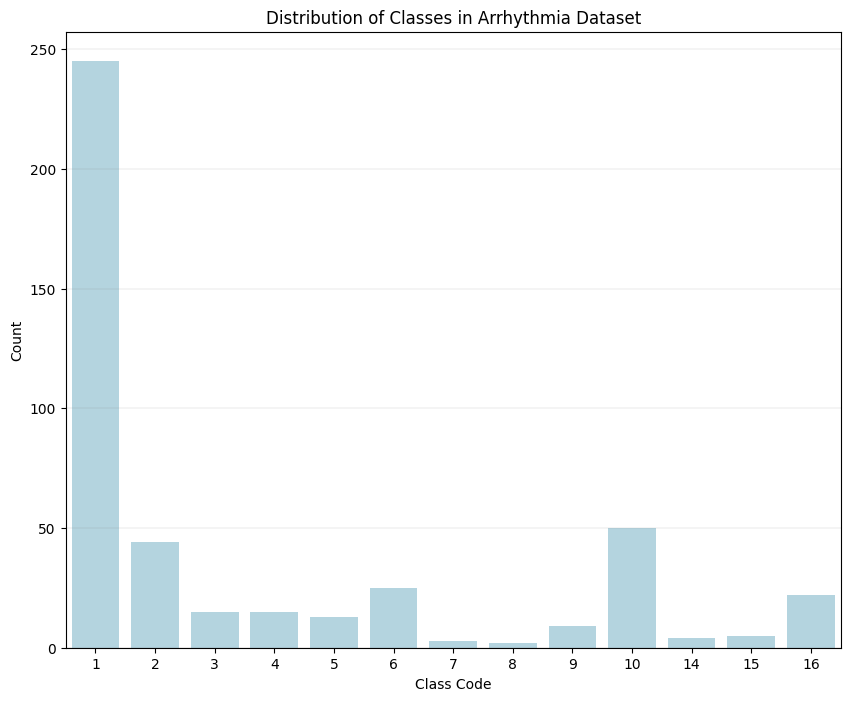

```python
# Plotting the class counts
plt.figure(figsize=(10, 8))
ax = sns.barplot(x='Class Code', y='Count', data=class_counts_not_dropped, color='lightblue')
plt.grid(axis='y', linestyle='-', color='gray', linewidth=0.25, alpha=0.5)
plt.title('Distribution of Classes in Arrhythmia Dataset')
plt.xlabel('Class Code')
plt.ylabel('Count')
plt.show()
```

# Anomaly Detection Task

## Data Preprocessing: handle missing values and standardize the features

- handle missing values by imputing the mean value for each feature.
- standardize the features to have a mean of 0 and a standard deviation of 1.

```python
# Checking missing values
df_not_dropped.isna().sum().sum()
```

```
408
```

```python
# Getting the mean for each feature
feature_means = df_not_dropped.mean()
```

```python
# Replacing the missing values with the mean for each feature
df_imputed = df_not_dropped.fillna(feature_means)
```

```python
# Checking for missing values again
df_imputed.isna().sum().sum()
```

```
0
```

```python
X_imputed = df_imputed.drop(columns=['diagnosis'])
y_imputed = df_imputed['diagnosis']
```

```python
scaler = StandardScaler()
```

```python
# Standardizing the features
X_imputed_scaled = scaler.fit_transform(X_imputed)
```

## PCA: Apply PCA to reduce the dimensionality of the dataset.

- Apply PCA to the standardized data, retaining enough components to explain 95% of the variance.

```python
# Retaining 95% of the variance for the PCA class
pca = PCA(n_components=0.95)
```

```python
# Applying PCA to the X_imputed_scaled_PCA
X_imputed_scaled_PCA = pca.fit_transform(X_imputed_scaled)
```

```python
# Checking the shape after PCA
X_imputed_scaled_PCA.shape
```

```
(452, 103)
```

## Anomaly Detection: Use the PCA-transformed data to detect anomalies.

- calculate the reconstruction error, which represents the difference between the original data and the reconstructed data using the reduced dimensionality.
- Identify Anomalies based on the reconstruction error exceeding a certain threshold (e.g. the 95th percentile of the reconstruction errors).
- Boxplot the anomalies (outliers). Reproduce following plot. Discuss your choice of threshold from this plot.

```python
# calculate the reconstruction error, which represents the difference between the original data and the reconstructed data using the reduced dimensionality.
X_reconstructed = pca.inverse_transform(X_imputed_scaled_PCA)
print("Reconstruction Error (MSE):", mean_squared_error(X_imputed_scaled, X_reconstructed))
```

```
Reconstruction Error (MSE): 0.0461241780979491
```

```python
# Identify Anomalies based on the reconstruction error exceeding a certain threshold (e.g. the 95th percentile of the reconstruction errors).
loss = np.sum((X_imputed_scaled - X_reconstructed) ** 2, axis=1)
normalized_loss = (loss - np.min(loss)) / (np.max(loss) - np.min(loss))
errors = pd.Series(data=normalized_loss)

threshold = np.percentile(errors, 95)
print(f"threshold: {threshold}")

anomalies = np.where(errors > threshold)

print(f"Anomaly Indices: {anomalies[0]}")
for i in anomalies[0]:
  print(f'Index: {i} | Anomaly: {errors[i]}')
```

```
threshold: 0.5432183867485985
Anomaly Indices: [ 36  86 106 139 150 153 189 190 234 241 257 271 299 300 303 306 321 322
 336 361 381 397 406]
Index: 36 | Anomaly: 0.5470067066101647
Index: 86 | Anomaly: 0.6785205751370855
Index: 106 | Anomaly: 0.5686508524699695
Index: 139 | Anomaly: 0.5693133912357772
Index: 150 | Anomaly: 0.7108548744242277
Index: 153 | Anomaly: 0.5900547182662634
Index: 189 | Anomaly: 0.6192124534066579
Index: 190 | Anomaly: 0.5755514755531949
Index: 234 | Anomaly: 0.8473663109329854
Index: 241 | Anomaly: 0.6890604647031408
Index: 257 | Anomaly: 0.5950839581797683
Index: 271 | Anomaly: 0.6053680529308366
Index: 299 | Anomaly: 0.6929916088054251
Index: 300 | Anomaly: 0.5720159709916024
Index: 303 | Anomaly: 0.5844793614406575
Index: 306 | Anomaly: 0.5891955422711942
Index: 321 | Anomaly: 0.6089256702530722
Index: 322 | Anomaly: 0.58379860103729
Index: 336 | Anomaly: 0.6238009074720482
Index: 361 | Anomaly: 0.5437571579502922
Index: 381 | Anomaly: 0.9030289378765842
Index: 397 | Anomaly: 0.8680341361238549
Index: 406 | Anomaly: 1.0
```

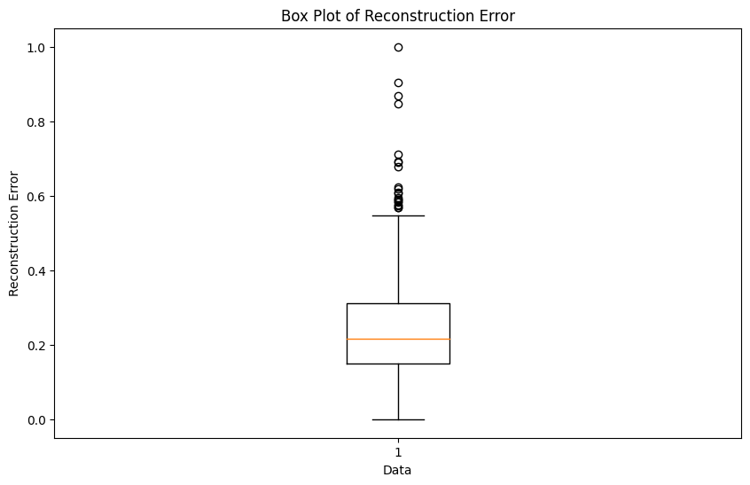

```
Threshold for anomalies: 0.550832070025888
```

```python
# Plotting the Box Plot
plt.figure(figsize=(10, 6))
plt.boxplot(errors)
plt.title("Box Plot of Reconstruction Error")
plt.xlabel("Data")
plt.ylabel("Reconstruction Error")
plt.show()

Q1 = np.percentile(errors, 25)
Q3 = np.percentile(errors, 75)
IQR = Q3 - Q1

threshold = Q3 + 1.5 * IQR
print(f"Threshold for anomalies: {threshold}")
```

## Reproduce the confusion matrix comparing the detected outliers and actual outliers in the dataset.

```python
# Checking the value counts for the True y
y_imputed.value_counts()
```

```
1     245
10     50
2      44
6      25
16     22
3      15
4      15
5      13
9       9
15      5
14      4
7       3
8       2
Name: diagnosis, dtype: int64
```

```python
# Standardizing the y_imputed
y_imputed_scaled = scaler.fit_transform(y_imputed.to_numpy().reshape(-1,1))
```

```python
# Unravelling the numpy array
y_imputed_scaled = y_imputed_scaled.ravel()
```

```python
# Converting the numpy array to a pd.Series to plot
y_imputed_scaled = pd.Series(y_imputed_scaled)
```

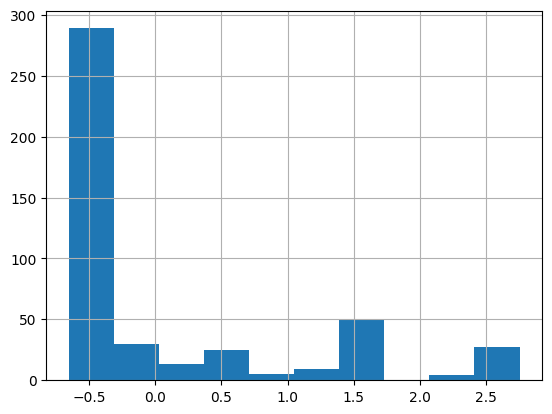

```python
# Plotting the distribution of y_imputed_scaled
y_imputed_scaled.hist()
```

```python
# Converting the target to useful labels, assuming anything above class 1 is an anomaly
class_label = y_imputed.apply(lambda x: 0 if x == 1 else 1)
```

```python
# Checking the binary classification
class_label
```

```
0      1
1      1
2      1
3      0
4      1
      ..
447    0
448    1
449    1
450    0
451    0
Name: diagnosis, Length: 452, dtype: int64
```

```python
# Checking the values counts
class_label.value_counts()
```

```
0    245
1    207
Name: diagnosis, dtype: int64
```

```python
# Setting a threshold for predicted anomalies
threshold = np.percentile(errors, 95)
threshold
```

```
0.5432183867485985
```

```python
# Connverting the predicted class labels into 0 (not anomaly) if its less than our threshold value, else its an anomaly
predicted_class_label = errors.apply(lambda x: 0 if x < threshold else 1)
```

```python
# Checking the value counts for our predicted class
predicted_class_label.value_counts()
```

```
0    429
1     23
dtype: int64
```

```python
# Creating a confusion matrix
cm = confusion_matrix(class_label, predicted_class_label)
cm
```

```
array([[235,  10],
       [194,  13]])
```

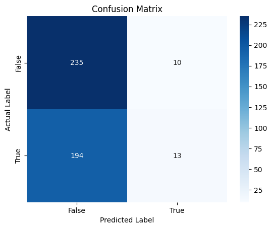

```python
# Making the confusion matrix look nicer
sns.heatmap(cm, annot=True, fmt='d', cmap='Blues', xticklabels=['False', 'True'], yticklabels=['False', 'True'])
plt.ylabel('Actual Label')
plt.xlabel('Predicted Label')
plt.title('Confusion Matrix')
plt.show()
```

## Reproduce the following plot showing detected outliers and actual outliers using first two PCs.

```python
# Converting so we only use the first two PCs
first_two = X_imputed_scaled_PCA[:, :2]
n_components = pca.n_components_
data_reduced = np.zeros(shape=(X_imputed_scaled_PCA.shape[0], n_components))
data_reduced[:, :2] = first_two
data_inverse_two_pca = pca.inverse_transform(data_reduced)
```

```python
# Converting into a dataframe
df_first_two = pd.DataFrame(first_two, columns=['PC1', 'PC2'])

# Finding the IQR
Q1 = df_first_two.quantile(0.25)
Q3 = df_first_two.quantile(0.75)
IQR = Q3 - Q1

# Defining our upper and lower bound
lower_bound = Q1 - 1.5 * IQR
upper_bound = Q3 + 1.5 * IQR

# Finding the outliers
outlier_data = df_first_two[((df_first_two < lower_bound) | (df_first_two > upper_bound)).any(axis=1)]

print(f"Number of outliers: {outlier_data.shape[0]}")
```

```
Number of outliers: 30
```

```python
# Reconstruction error
loss_2 = np.sum((X_imputed_scaled - data_inverse_two_pca) ** 2, axis=1)
normalized_loss_2 = (loss_2 - np.min(loss_2)) / (np.max(loss_2) - np.min(loss_2))
anomaly_scores_2 = pd.Series(data=normalized_loss_2)

threshold_2 = np.percentile(anomaly_scores_2, 95)

print(f"The threshold is {threshold_2}")

anomalies_2 = np.where(anomaly_scores_2 > threshold_2)[0]

anomalies_series_2 = pd.Series(anomaly_scores_2[anomalies_2], index=anomalies_2)

print(anomalies_series_2)
```

```
The threshold is 0.31443420806623384
76     0.507962
85     0.724400
88     0.326256
108    0.498179
116    0.315177
133    0.366059
141    1.000000
204    0.497862
207    0.405084
213    0.405144
218    0.614961
297    0.565333
308    0.393552
312    0.397815
318    0.398043
354    0.475001
363    0.338066
370    0.330875
379    0.885820
388    0.399453
403    0.422311
424    0.315100
449    0.563177
dtype: float64
```

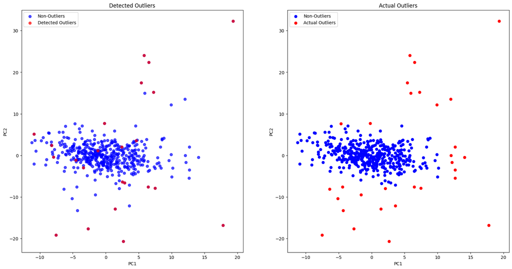

```python
# Plotting the Detected and Acual Outliers
plt.figure(figsize=(20, 10))
plt.subplot(1, 2, 1)  # 1 row, 2 columns, 1st subplot

# Plot not outliers as blue
plt.scatter(first_two[:, 0], first_two[:, 1], color='blue', label='Non-Outliers', alpha=0.7)

# Plot outliers as red
plt.scatter(first_two[anomalies_2, 0], first_two[anomalies_2, 1], color='red', label='Detected Outliers', alpha=0.7)
plt.xlabel('PC1')
plt.ylabel('PC2')
plt.title('Detected Outliers')
plt.legend()

plt.subplot(1, 2, 2)

# Plotting Non-Outliers
plt.scatter(df_first_two.loc[~((df_first_two < lower_bound) | (df_first_two > upper_bound)).any(axis=1), 'PC1'], df_first_two.loc[~((df_first_two < lower_bound) | (df_first_two > upper_bound)).any(axis=1), 'PC2'], color='blue', label='Non-Outliers')
# Plotting Outliers
plt.scatter(df_first_two.loc[((df_first_two < lower_bound) | (df_first_two > upper_bound)).any(axis=1), 'PC1'], df_first_two.loc[((df_first_two < lower_bound) | (df_first_two > upper_bound)).any(axis=1), 'PC2'], color='red', label='Actual Outliers')

plt.xlabel('PC1')
plt.ylabel('PC2')
plt.title('Actual Outliers')
plt.legend()
plt.show()
```